# Complexity Analysis & Recurrence Relations

**Complexity analysis** is the study of how an algorithm's resource usage (like time or memory) scales with the size of the input. It's crucial for:

- **Evaluating Efficiency**: Comparing algorithms to find the most efficient one.
- **Predicting Scalability**: Understanding how an algorithm will perform with large datasets.
- **Informed Decisions**: Choosing the right algorithm for a specific problem.

## Recurrence Relations

Recurrence relations are equations that define a sequence of values based on previous values in the sequence. They are often used to describe the time complexity of recursive algorithms.

A common form of a recurrence relation is

```
plaintext
                    T(n) = aT(n/b) + f(n)
```

Where:

- `n`: Size of the problem.
- `a`: Number of subproblems in the recursion (`a ≥ 1`).
- `b`: Factor by which the problem size is reduced in each subproblem (`b > 1`).
- `n/b`: Size of each subproblem (`b > 1`).
- `T(n)`: Total time complexity for the problem of size `n`.
- `f(n)`: Cost of the work done outside the recursive calls (dividing the problem and combining results).

## Substitution Method

The **substitution method** is a technique for solving recurrence relations by guessing a form for the solution and then using mathematical induction to prove it.

Example:

We have the following relationship:

[output not shown]

T(n) = T(n/2) + 1 T(n/2) = T(n/4) + 1 ->(1) T(n/4) = T(n/8) + 1 ->(2) ... T(n) = T(n/4) + 1 + 1 -> substituting (1) T(n) = T(n/8) + 1 + 1 + 1 -> substituting (2) ... Continuing this process, we find that:

```
plaintext
T(n) = T(n/2^k) + k
```

Where `k` is the number of times we can divide `n` by `2` until we reach the base case (when `n = 1`).

to find 'k':

```
math
n/2^k = 1

<=> n = 2^k

<=> k = log_2(n)
```

Substituting `k` back into the equation gives:

```
plaintext
T(n) = T(n/2^{log_2(n)}) + log_2(n)
T(n) = T(n/n) + log_2(n)
T(n) = T(1) + log_2(n)
T(n) = 1 + log_2(n)
T(n) = Θ(log n)
```

## Master Theorem

The **Master Theorem** provides a way to analyze the time complexity of divide-and-conquer algorithms that fit the form of the recurrence relation mentioned above. It gives a straightforward way to determine the complexity without solving the recurrence directly.

```
plaintext
T(n) = aT(n/b) + f(n)
```

We compare `f(n)` with $n^{\log_b a}$. The theorem has three cases:

1. **Case 1**: If $f(n) = O(n^{\log_b a - \epsilon})$ for some constant $\epsilon > 0$, then $T(n) = \Theta(n^{\log_b a})$. *(The cost of the subproblems dominates.)*
2. **Case 2**: If $f(n) = \Theta(n^{\log_b a})$, then $T(n) = \Theta(n^{\log_b a} \log n)$. *(The cost is evenly distributed between subproblems and the dividing/combining step.)*
3. **Case 3**: If $f(n) = \Omega(n^{\log_b a + \epsilon})$ for some constant $\epsilon > 0$, and if $a f(n/b) \le c f(n)$ for some constant $c < 1$ and sufficiently large $n$ (the "regularity condition"), then $T(n) = \Theta(f(n))$. *(The cost of dividing/combining dominates.)*

### Example: Merge Sort

The recurrence for Merge Sort is $T(n) = 2T(n/2) + n$.

- `a = 2`, `b = 2`, `f(n) = n`
- Calculate $n^{\log_b a} = n^{\log_2 2} = n^1 = n$.
- Compare $f(n)$ with $n$. Since $f(n) = n = \Theta(n)$, this fits **Case 2**.
- Therefore, the complexity is $T(n) = \Theta(n \log n)$.

#### Question

Graph the functions $8n$, $4 n log(n)$, $2n^2$, $n3$, and $2n$ using a logarithmic scale for the $x$-axis and $y$-axes; that is, if the function value $f(n)$ is $y$, plot this as a point with $$x$-coordinate at $log(n)$ and $y$-coordinate at $log(y)$.

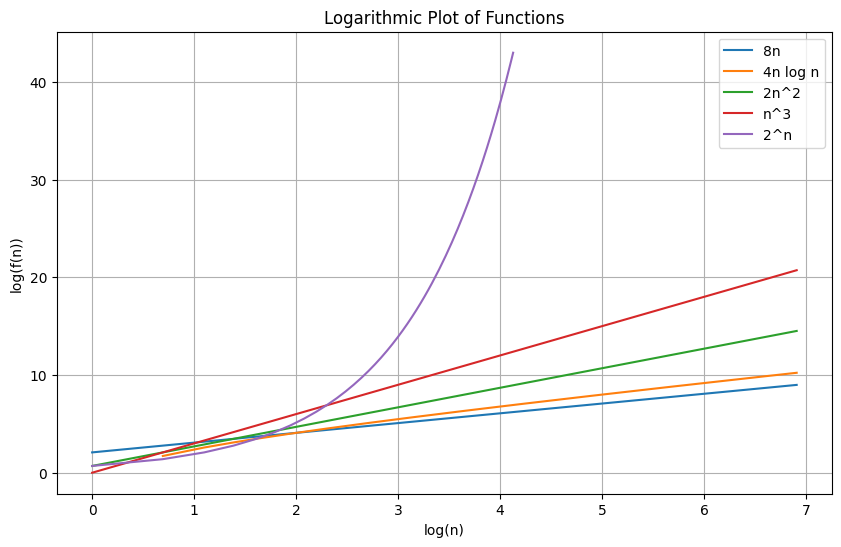

```python
import matplotlib.pyplot as plt
import numpy as np

def plot_functions():
    n = np.arange(1, 1000, 1)
    functions = {
        '8n': 8 * n,
        '4n log n': 4 * n * np.log(n),
        '2n^2': 2 * n**2,
        'n^3': n**3,
        '2^n': 2**n
    }

    plt.figure(figsize=(10, 6))

    for label, values in functions.items():
        plt.plot(np.log(n), np.log(values), label=label)

    plt.xlabel('log(n)')
    plt.ylabel('log(f(n))')
    plt.title('Logarithmic Plot of Functions')
    plt.legend()
    plt.grid(True)
    plt.show()

plot_functions()
```

#### Question

The recurrence relation for naive matrix multiplication is as follows:

$T (n) = 8T (n/2) + Θ(n^2)$

$T (1) = 1.$

Derive the worst-case running time complexity of naive matrix multiplication.

#### Question

The recurrence relation for the Strassen algorithm is as follows:

$T (n) = 7T (n/2) + Θ(n²)$

$T (1) = 1.$

Derive the worst-case running time complexity of the Strassen algorithm.

#### Question

Can we solve all recurrence relations using the Master Theorem? If not, what are some limitations?

#### Question

What is recurrence relation? Can you give an example of a recurrence relation that is not solvable by the Master Theorem?